# Do contraceptive methods change the vaginal environment?

Study B — 93 samples · pill / injectable / ring

## Background & question

**The setting**

- Hormonal contraception is used by millions of women, but its effect on the vaginal environment is not well mapped.
- The “vaginal environment” has three layers we can measure: **who is there** (220 bacterial species), **what the tissue is doing** (~14,000 human genes), and **immune signalling** (15 cytokines).

**Our two questions**

1. Do the three hormonal methods (pill, injectable, ring) produce different vaginal microbiomes or transcriptomes?
2. Does **community type** — *Lactobacillus*-dominant vs diverse — explain gene activity better than the method does?

## Study design

- **Cohort:** 93 women, one sample each, cross-sectional.
- **Three arms:** pill, injectable, ring — all hormonal, but the ring acts *locally* in the vagina while pill and injectable act *systemically*.
- **Three data types per sample:** species counts (220 × 93), RNA-seq gene counts (14,226 × 93), cytokines (15 per sample).
- **Design is clean:** sequencing batches are balanced across arms (47 vs 46 samples), and BV / STI prevalence is spread across arms — nothing is confounded with the method.
- **Key rule we follow:** community type is defined **from the species table only**, then tested **on the gene table** — never define a group from one table and test that same table.

## Quality control — the gate before any test

| Check | Result |
| --- | --- |
| Count-table columns match metadata rows, both tables | **PASS** |
| No duplicate or unmatched sample IDs | **PASS** |
| All 220 species + all 14,226 genes annotated | **PASS** |
| Metadata complete; `bv` label matches Nugent score bands | **PASS** |
| Sequencing depth: shallowest sample 5,247 reads | **PASS** — nothing near our 1,000-read line |
| Batch vs arm cross-table: no confounding | **PASS** |
| Cytokines: `B018`, `B029` missing **all 15** values | **FLAG** — dropped from cytokine analyses only |

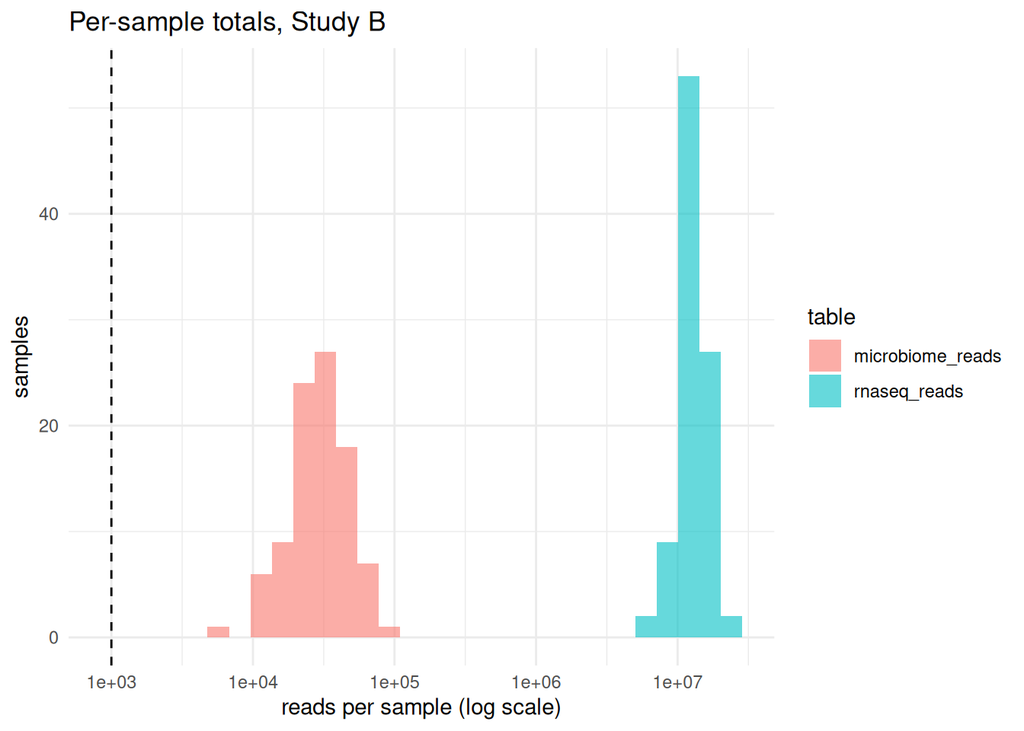

Sequencing depth of every sample, both tables (log scale). All samples sit well past the 1,000-read line.

**Carry-forward: all 93 samples into microbiome & RNA-seq; 91 into cytokine analyses.** Full audit trail with spot-checks: `01-qc-report.html`.

## Methods — and why we chose them

- **Community type:** fraction of reads from *Lactobacillus* ≥ 50% → `lacto-dominant` (48 samples), else `diverse` (45). Both types occur in all three arms, so the two groupings are not copies of each other.
- **Overall differences:** ordination (PCoA) + **PERMANOVA** (999 permutations, `by = "margin"`).
  - Species: **Bray–Curtis** distance.
  - Genes: **CLR transform + Euclidean** — raw gene counts would let a few very highly expressed genes dominate Bray–Curtis.
- **Per-gene differences:** **DESeq2 on raw counts** (never CPM or logged — it normalises itself), design `~ rnaseq_batch + arm` (or `+ community`), genes kept if ≥ 10 counts in ≥ 24 samples, **FDR 0.05** across ~14,000 tests.
- **BV status included as a yardstick** — a known biological effect, so our method effect has a sense of scale.

## Results 1 — the methods barely differ

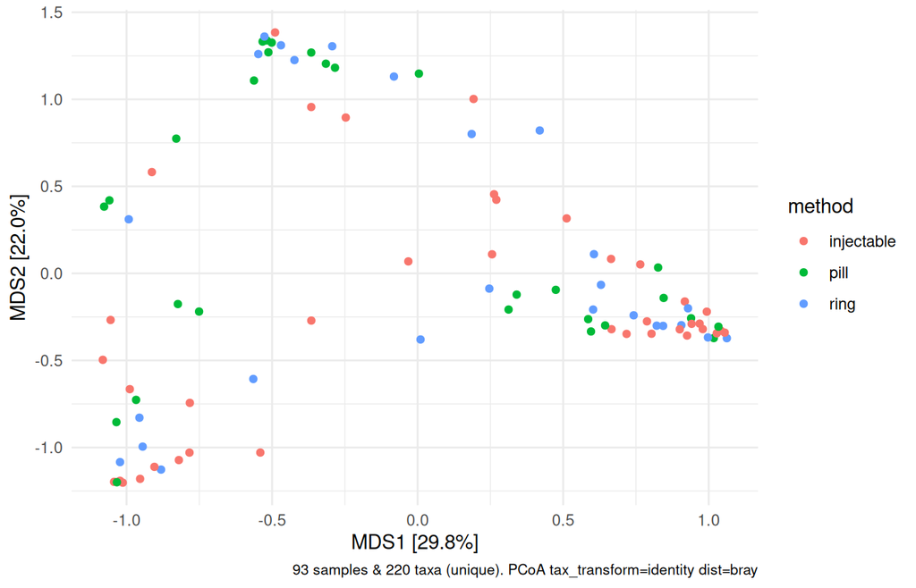

Species composition (Bray–Curtis PCoA). Points coloured by method overlap.

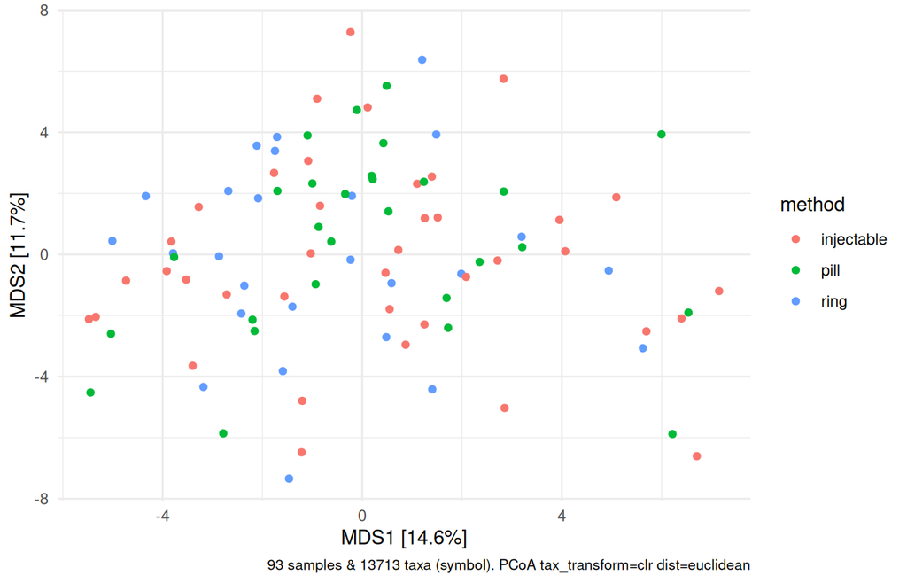

Gene activity (CLR + Euclidean PCoA), coloured by method.

| Test | Result |
| --- | --- |
| Species PERMANOVA | method R² **~3%**, p ≈ 0.08 — vs **~22%** for BV (yardstick) |
| Gene PERMANOVA | method R² **~2.7%**, not significant |
| DESeq2 pairwise (13,713 genes) | injectable vs pill **10** FDR genes; ring vs pill and ring vs injectable ≈ **100–140** each |

## Results 2 — community type leaves a gene signature

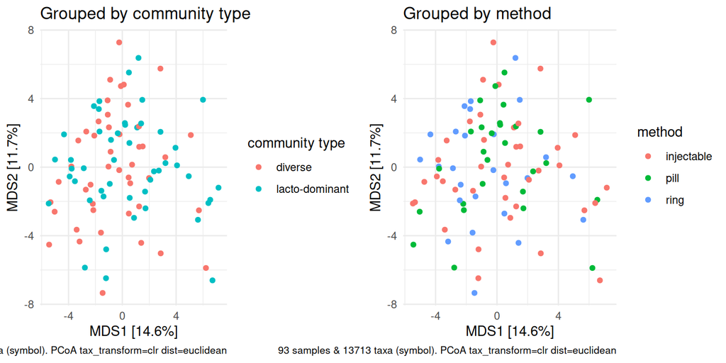

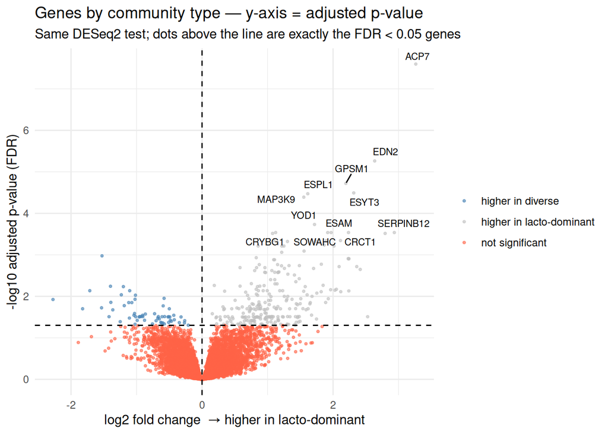

Volcano plot of the lacto-dominant vs diverse test — y-axis = adjusted p (FDR); 310 genes above the line.

| Community vs method, head-to-head on genes | Result |
| --- | --- |
| Gene PERMANOVA (both terms in one model) | method **~2.6%** vs community **~1.5%** — both ns |
| DESeq2 gene counts passing FDR | community **310** vs best method contrast **136** |